# Using ApproxMAPR: The long example

Corey Bryant

2/24/2021

## Getting started

The first thing that needs to be completed is installing ApproxmapR if it is not already done.

### Installing ApproxmapR

At this time ApproxmapR is not on CRAN and must be installed using the GitHub version. This can be done with the following code:

```
library(devtools)
devtools::install_github("pinformatics/approxmapR")
```

The above code will install the latest version.

### Loading Library

Now to load the required libraries.

```r
library(approxmapR)
library(kableExtra)
library(knitr)
options(knitr.table.format = "html")
library(tidyverse)
```

### Loading Data Frame

ApproxmapR comes with a few example data sets that can be loaded. For this example, the “demo1” data set will be used. The data needs to have minor manipulation to get it ready.

```r
data("demo1")
demo1 <- data.frame(do.call("rbind", strsplit(as.character(demo1$id.date.item), ",")))
names(demo1) <- c("id", "period", "event")

head(demo1)
```

```
##   id    period event
## 1  1  1/2/2017     A
## 2  1 1/10/2017     B
## 3  1 1/11/2017     C
## 4  1 1/12/2017     Y
## 5  1 1/20/2017     D
## 6  2  1/2/2017     A
```

## The Process

As can be seen above, the data set has 3 columns: “id”, “period”, and “event”. The “id” column is an identifier, the “period” is a date variable which represents the period (a grouping variable), and “event” which is the event that occurred. These three column names and order are specific and required.

### Aggregating the Data

There are two functions available to aggregate the data, pre_aggregated() and aggregate_sequences(). The pre_aggregated() function is used on data were the “period” column is a single identifier (ex. A, B, C, etc) while the aggregate_sequences() function is used on datetime or date data and will aggregate by “day”, “week”, “month”, “6 months”, and “year”.

```r
agg_df <-  demo1 %>% aggregate_sequences(format = "%m/%d/%Y",
                                         unit = "month",
                                         n_units = 1,
                                         summary_stats = FALSE)
```

```
## # A tibble: 51 x 5
## # Groups:   id [10]
##    id    date       event n_ndays agg_n_ndays
##    <chr> <date>     <chr>   <dbl>       <dbl>
##  1 1     2017-01-02 A       0               1
##  2 1     2017-01-10 B       0.267           1
##  3 1     2017-01-11 C       0.3             1
##  4 1     2017-01-12 Y       0.333           1
##  5 1     2017-01-20 D       0.6             1
##  6 2     2017-01-02 A       0               1
##  7 2     2017-01-10 B       0.267           1
##  8 2     2017-01-11 C       0.3             1
##  9 2     2017-01-12 Y       0.333           1
## 10 2     2017-01-20 D       0.6             1
## # ... with 41 more rows
```

```r
head(agg_df)
```

```
## # A tibble: 6 x 3
## # Groups:   id, period, event [6]
##   id    period event
##   <chr>  <int> <chr>
## 1 1          1 A
## 2 1          1 B
## 3 1          1 C
## 4 1          1 D
## 5 1          1 Y
## 6 10         1 K
```

For documentation use ??aggregate_sequences() or ??pre_aggregated(). The -n_units- is specifying how many -units- to be considered within the period. The above indicates the events are to be aggregated based on the month and to considered 1 month as a period. If -n_units- were to equal 2, then that would indicate to aggregate based on the month and to considered 2 months as a period.

### Finding Optimal K Value

This step is not required but is highly encouraged. By finding the optimal K value, one can proceed with a piece of mind knowing that the best clustering has been achieved. Currently two clustering algorithms are supported, K-NN and K-Medoids.

The -find_optimal_k()- function will output a data frame with all the tested k values, the number of clusters produced, the size of each cluster, all of the supported cluster validation measures, and a plot of K values by validation measure. For more information use ??find_optimal_k.

A special note about the -use_cache- parameter within the -find_optimal_k()- function. This parameter will indicate that the distance matrix calculated should be one that has already been calculated; if it does not yet exist then the distance matrix will be calculated and stored as an environment variable. For those interested, this environment variable can be accessed by using:

```
env_dm$distance_matrix
```

This feature is beneficial when use massive data sets as distance calculation is expensive in terms of processing.

#### Example: Optimal K using K-Medoids

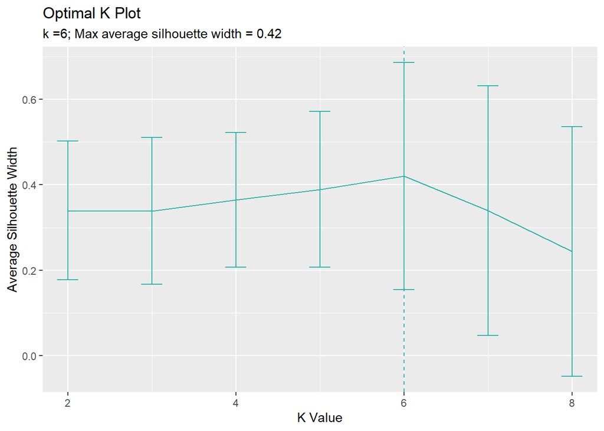

```
##   k n_clusters           cluster_size average_silhouette_width_lower_ci
## 1 2          2                   3, 7                        0.17760809
## 2 3          3                3, 1, 6                        0.16719637
## 3 4          4             3, 1, 2, 4                        0.20668370
## 4 5          5          3, 1, 2, 3, 1                        0.20693015
## 5 6          6       2, 1, 2, 1, 3, 1                        0.15494015
## 6 7          7    2, 1, 1, 1, 3, 1, 1                        0.04714664
## 7 8          8 2, 1, 1, 1, 1, 2, 1, 1                       -0.04845349
##   average_silhouette_width average_silhouette_width_upper_ci      dunn
## 1                0.3397857                         0.5019633 0.6000000
## 2                0.3387528                         0.5103092 0.6857143
## 3                0.3644922                         0.5223007 0.6818182
## 4                0.3890157                         0.5711013 0.9000000
## 5                0.4203102                         0.6856802 1.2500000
## 6                0.3394167                         0.6316867 1.1428572
## 7                0.2438095                         0.5360725 1.2500000
##   average_within average_between  wb_ratio within_cluster_ss
## 1      0.5971429       0.9140332 0.6533054        1.78265802
## 2      0.5304938       0.9117525 0.5818398        1.22389791
## 3      0.4358025       0.8673995 0.5024242        0.71947662
## 4      0.3576389       0.8533066 0.4191212        0.38733542
## 5      0.2500000       0.8384190 0.2981803        0.18157408
## 6      0.1900000       0.8277259 0.2295446        0.10157408
## 7      0.1333333       0.8051185 0.1656071        0.03555556
```

```r
agg_df %>% find_optimal_k(clustering = 'k-medoids',
                          min_k = 2, max_k = 8,
                          validation_measure = 'silhouette',
                          use_cache = TRUE)
```

Based on the average silhouette measure, K = 6 should be used for the K-Medoids algorithm.

### Clustering

Currently there are two clustering algorithms supported, K-NN and K-Medoids, and each have their own separate clustering function. To run the K-NN clustering algorithm use -cluster_knn()-; to run the K-Medoids algorithm use -cluster_kmedoids()-.

```r
clustered_kmed <- agg_df %>% cluster_kmedoids(k = 6, use_cache = TRUE)
```

```
## Clustering...
```

```
## Using cached distance matrix...
```

```
## Clustering Based on PAM Algorithm
```

```
## ----------Done Clustering----------
```

#### The Clustered Data Frame

The resulting data frame will show 3 columns: “cluster”, “df_sequences”, and “n”. Cluster is the cluster number, df_sequences contains a data frame which has the original id and the sequence resulting from that id, and n is the number of sequences within the cluster.

```r
clustered_kmed
```

```
## # A tibble: 6 x 3
##   cluster df_sequences         n
##     <int> <list>           <int>
## 1       5 <tibble [3 x 2]>     3
## 2       1 <tibble [2 x 2]>     2
## 3       3 <tibble [2 x 2]>     2
## 4       2 <tibble [1 x 2]>     1
## 5       4 <tibble [1 x 2]>     1
## 6       6 <tibble [1 x 2]>     1
```

Reading the first row one sees that it is cluster #5 which has 3 sequences within the cluster. Let’s take a quick look at the df_sequences column for more intuition.

```r
clustered_kmed$df_sequences[[1]]
```

```
## # A tibble: 3 x 2
##   id    sequence
##   <chr> <Sqnc_Lst>
## 1 5     <Sequence [2]>
## 2 6     <Sequence [2]>
## 3 7     <Sequence [2]>
```

Now to take a look at the sequences themselves.

```r
clustered_kmed$df_sequences[[1]]$sequence
```

```
## 5 :  <(B, I, J) (K, L)>
## 6 :  <(I, J) (L, M)>
## 7 :  <(I, J, K) (J, K, L, M)>
```

For a bit more intuition on the sequences themselves a closer look at the period and events where id = 5.

```r
agg_df %>% filter(id == 5)
```

```
## # A tibble: 5 x 3
## # Groups:   id, period, event [5]
##   id    period event
##   <chr>  <int> <chr>
## 1 5          1 B
## 2 5          1 I
## 3 5          1 J
## 4 5          2 K
## 5 5          2 L
```

Notice how events B, I, and J are within the same set - as well as events K and L are in the same set, but different than B, I, and J. This is because events B, I, and J occurred during the first period, while events K and L occurred during a different period.

### Pulling the Pattern

Next step is to pull the pattern, this is completed by specifying a strength threshold. This pulls the events within a weighted sequence that is shared by the majority of sequences within a cluster; for more information please see Kum, H. C., Pei, J, Wang, W., and Duncan, D. (2002). ApproxMAP: Approximate Mining of Consensus Sequential Patterns. Technical Report TR02-031, UNC-CH, 2002. Published in Mining Sequential Patterns from Large Data Sets. Springer Series: The Kluwer International Series on Advances in Database Systems, Vol. 28. Wang, W. & Yang, J. pp. 138-160.

```r
patterns_kmed <- clustered_kmed %>%
                    filter_pattern(threshold = 0.3,
                                   pattern_name = 'consensus')
```

### Generating Reports

The final step is to generate a report based on the threshold.

```
patterns_kmed %>% generate_reports(end_filename_with = "_kmed")
```